# **Predicting Compressive Strength of Concrete**

## Bagging Regressor

```python
model=BaggingRegressor()
model.fit(X_train, y_train)
```

```
BaggingRegressor(base_estimator=None, bootstrap=True, bootstrap_features=False,
                 max_features=1.0, max_samples=1.0, n_estimators=10,
                 n_jobs=None, oob_score=False, random_state=None, verbose=0,
                 warm_start=False)
```

```python
y_pred = model.predict(X_test)
```

```python
model.score(X_train,y_train)
```

```
0.9753431727022379
```

```python
model.score(X_test,y_test)
```

```
0.8719511247570841
```

```python
acc_BR=metrics.r2_score(y_test, y_pred)
acc_BR
```

```
0.871951124757084
```

```python
metrics.mean_squared_error(y_test, y_pred)
```

```
33.5625320267391
```

```python
Bagging_df = pd.DataFrame({'Algorithm':['Bagging Regressor'], 'accuracy': [acc_BR]},index={'9'})
results = pd.concat([results, Bagging_df ])
results = results[['Algorithm', 'accuracy']]
results
```

|  | Algorithm | accuracy |
| --- | --- | --- |
| 1 | Random Forest | 0.877429 |
| 2 | Random Forest Regressor k_fold | 0.766505 |
| 3 | Gradient Boost Regressor | 0.880352 |
| 4 | Gradient Boost Regressor k fold | 0.770140 |
| 5 | Ada Boosting Regressor | 0.754750 |
| 6 | Ada Boosting Regressor k fold | 0.598713 |
| 7 | KNN Regressor | 0.753949 |
| 8 | KNN Regressor k fold | 0.690711 |
| 9 | Bagging Regressor | 0.871951 |

### KFold Cross Validation

```python
k= 20

kfold = KFold(n_splits=k, random_state=70)
results_6 = cross_val_score(model,X, y, cv=kfold)
accuracy=np.mean(abs(results_6 ))
accuracy
```

```
0.7375660519203044
```

```python
BaggingKFold_df = pd.DataFrame({'Algorithm':['Bagging Regressor k fold'], 'accuracy': [accuracy]},index={'10'})
results = pd.concat([results,BaggingKFold_df ])
results = results[['Algorithm', 'accuracy']]
results
```

|  | Algorithm | accuracy |
| --- | --- | --- |
| 1 | Random Forest | 0.877429 |
| 2 | Random Forest Regressor k_fold | 0.766505 |
| 3 | Gradient Boost Regressor | 0.880352 |
| 4 | Gradient Boost Regressor k fold | 0.770140 |
| 5 | Ada Boosting Regressor | 0.754750 |
| 6 | Ada Boosting Regressor k fold | 0.598713 |
| 7 | KNN Regressor | 0.753949 |
| 8 | KNN Regressor k fold | 0.690711 |
| 9 | Bagging Regressor | 0.871951 |
| 10 | Bagging Regressor k fold | 0.737566 |

## Support Vector Regressor

```python
model = SVR(kernel='linear')
model.fit(X_train, y_train)
```

```
SVR(C=1.0, cache_size=200, coef0=0.0, degree=3, epsilon=0.1, gamma='scale',
    kernel='linear', max_iter=-1, shrinking=True, tol=0.001, verbose=False)
```

```python
y_pred = model.predict(X_test)
```

```python
model.score(X_train,y_train)
```

```
0.7296525761559518
```

```python
model.score(X_test,y_test)
```

```
0.6549962611822544
```

```python
acc_SVR=metrics.r2_score(y_test, y_pred)
acc_SVR
```

```
0.6549962611822544
```

```python
metrics.mean_squared_error(y_test, y_pred)
```

```
90.42796363067555
```

```python
SVR_df = pd.DataFrame({'Algorithm':['Support Vector Regressor'], 'accuracy': [acc_SVR]},index={'11'})
results = pd.concat([results, SVR_df])
results = results[['Algorithm', 'accuracy']]
results
```

|  | Algorithm | accuracy |
| --- | --- | --- |
| 1 | Random Forest | 0.877429 |
| 2 | Random Forest Regressor k_fold | 0.766505 |
| 3 | Gradient Boost Regressor | 0.880352 |
| 4 | Gradient Boost Regressor k fold | 0.770140 |
| 5 | Ada Boosting Regressor | 0.754750 |
| 6 | Ada Boosting Regressor k fold | 0.598713 |
| 7 | KNN Regressor | 0.753949 |
| 8 | KNN Regressor k fold | 0.690711 |
| 9 | Bagging Regressor | 0.871951 |
| 10 | Bagging Regressor k fold | 0.737566 |
| 11 | Support Vector Regressor | 0.654996 |

**KFold Cross Validation SVR**

```python
k= 10

kfold = KFold(n_splits=k, random_state=70)
results_6 = cross_val_score(model,X, y, cv=kfold)
accuracy=np.mean(abs(results_6))
accuracy
```

```
0.6685376577727407
```

```python
SVRKFold_df = pd.DataFrame({'Algorithm':['SVR k fold'], 'accuracy': [accuracy]},index={'12'})
results = pd.concat([results, SVRKFold_df ])
results = results[['Algorithm', 'accuracy']]
results
```

|  | Algorithm | accuracy |
| --- | --- | --- |
| 1 | Random Forest | 0.877429 |
| 2 | Random Forest Regressor k_fold | 0.766505 |
| 3 | Gradient Boost Regressor | 0.880352 |
| 4 | Gradient Boost Regressor k fold | 0.770140 |
| 5 | Ada Boosting Regressor | 0.754750 |
| 6 | Ada Boosting Regressor k fold | 0.598713 |
| 7 | KNN Regressor | 0.753949 |
| 8 | KNN Regressor k fold | 0.690711 |
| 9 | Bagging Regressor | 0.871951 |
| 10 | Bagging Regressor k fold | 0.737566 |
| 11 | Support Vector Regressor | 0.654996 |
| 12 | SVR k fold | 0.668538 |

## XGBoost Regressor

```python
import xgboost as xgb
from xgboost.sklearn import XGBRegressor

xgr =XGBRegressor()

xgr.fit(X_train, y_train)
```

```
[11:31:08] WARNING: src/objective/regression_obj.cu:152: reg:linear is now deprecated in favor of reg:squarederror.
```

```
XGBRegressor(base_score=0.5, booster='gbtree', colsample_bylevel=1,
             colsample_bynode=1, colsample_bytree=1, gamma=0,
             importance_type='gain', learning_rate=0.1, max_delta_step=0,
             max_depth=3, min_child_weight=1, missing=None, n_estimators=100,
             n_jobs=1, nthread=None, objective='reg:linear', random_state=0,
             reg_alpha=0, reg_lambda=1, scale_pos_weight=1, seed=None,
             silent=None, subsample=1, verbosity=1)
```

```python
y_pred = xgr.predict(X_test)
```

```python
xgr.score(X_train,y_train)
```

```
0.9441437766049378
```

```python
xgr.score(X_test,y_test)
```

```
0.8818060857485882
```

```python
acc_XGB=metrics.r2_score(y_test, y_pred)
acc_XGB
```

```
0.8818060857485882
```

```python
metrics.mean_squared_error(y_test, y_pred)
```

```
30.979475804869445
```

```python
XGB_df = pd.DataFrame({'Algorithm':['XGBoast'], 'accuracy': [acc_XGB]},index={'13'})
results = pd.concat([results,XGB_df  ])
results = results[['Algorithm', 'accuracy']]
results
```

|  | Algorithm | accuracy |
| --- | --- | --- |
| 1 | Random Forest | 0.877429 |
| 2 | Random Forest Regressor k_fold | 0.766505 |
| 3 | Gradient Boost Regressor | 0.880352 |
| 4 | Gradient Boost Regressor k fold | 0.770140 |
| 5 | Ada Boosting Regressor | 0.754750 |
| 6 | Ada Boosting Regressor k fold | 0.598713 |
| 7 | KNN Regressor | 0.753949 |
| 8 | KNN Regressor k fold | 0.690711 |
| 9 | Bagging Regressor | 0.871951 |
| 10 | Bagging Regressor k fold | 0.737566 |
| 11 | Support Vector Regressor | 0.654996 |
| 12 | SVR k fold | 0.668538 |
| 13 | XGBoast | 0.881806 |

## DecisionTree Regression

```python
dec_model = DecisionTreeRegressor()
dec_model.fit(X_train , y_train)
```

```
DecisionTreeRegressor(ccp_alpha=0.0, criterion='mse', max_depth=None,
                      max_features=None, max_leaf_nodes=None,
                      min_impurity_decrease=0.0, min_impurity_split=None,
                      min_samples_leaf=1, min_samples_split=2,
                      min_weight_fraction_leaf=0.0, presort='deprecated',
                      random_state=None, splitter='best')
```

```python
#printing the feature importance
print('Feature importances: \n',pd.DataFrame(dec_model.feature_importances_,columns=['Importance'],index=X_train.columns))
```

```
Feature importances:
               Importance
cement          0.309570
slag            0.058796
ash             0.007969
water           0.124096
superplastic    0.047146
coarseagg       0.027319
fineagg         0.052125
age             0.372979
```

As we can see, cement, age and water are the most important features.

On the other hand, ash, coarseagg, fineagg, superplastic and slag are the less important features and will have less impact on the strength

```python
y_pred = dec_model.predict(X_test)
```

```python
dec_model.score(X_train,y_train)
```

```
0.9930841416603411
```

```python
dec_model.score(X_test,y_test)
```

```
0.7649920875174039
```

```python
acc_DT=metrics.r2_score(y_test, y_pred)
acc_DT
```

```
0.7649920875174039
```

```python
metrics.mean_squared_error(y_test, y_pred)
```

```
61.59726568680332
```

```python
XGB_df = pd.DataFrame({'Algorithm':['Decision Tree'], 'accuracy': [acc_DT]},index={'14'})
results = pd.concat([results,XGB_df])
results = results[['Algorithm', 'accuracy']]
results
```

|  | Algorithm | accuracy |
| --- | --- | --- |
| 1 | Random Forest | 0.877429 |
| 2 | Random Forest Regressor k_fold | 0.766505 |
| 3 | Gradient Boost Regressor | 0.880352 |
| 4 | Gradient Boost Regressor k fold | 0.770140 |
| 5 | Ada Boosting Regressor | 0.754750 |
| 6 | Ada Boosting Regressor k fold | 0.598713 |
| 7 | KNN Regressor | 0.753949 |
| 8 | KNN Regressor k fold | 0.690711 |
| 9 | Bagging Regressor | 0.871951 |
| 10 | Bagging Regressor k fold | 0.737566 |
| 11 | Support Vector Regressor | 0.654996 |
| 12 | SVR k fold | 0.668538 |
| 13 | XGBoast | 0.881806 |
| 14 | Decision Tree | 0.764992 |

```python
k = 18

kfold = KFold(n_splits=k, random_state=70)
results_7= cross_val_score(dec_model,X, y, cv=kfold)
accuracy=np.mean(abs(results_7))
accuracy
```

```
0.7682776055345931
```

```python
DecKFold_df = pd.DataFrame({'Algorithm':['Decision Tree k fold'], 'accuracy': [accuracy]},index={'15'})
results = pd.concat([results, DecKFold_df])
results = results[['Algorithm', 'accuracy']]
results
```

|  | Algorithm | accuracy |
| --- | --- | --- |
| 1 | Random Forest | 0.877429 |
| 2 | Random Forest Regressor k_fold | 0.766505 |
| 3 | Gradient Boost Regressor | 0.880352 |
| 4 | Gradient Boost Regressor k fold | 0.770140 |
| 5 | Ada Boosting Regressor | 0.754750 |
| 6 | Ada Boosting Regressor k fold | 0.598713 |
| 7 | KNN Regressor | 0.753949 |
| 8 | KNN Regressor k fold | 0.690711 |
| 9 | Bagging Regressor | 0.871951 |
| 10 | Bagging Regressor k fold | 0.737566 |
| 11 | Support Vector Regressor | 0.654996 |
| 12 | SVR k fold | 0.668538 |
| 13 | XGBoast | 0.881806 |
| 14 | Decision Tree | 0.764992 |
| 15 | Decision Tree k fold | 0.768278 |

```python
df2=df.copy() #create a copy of df in order to drop least important features and work on it while not messing up our original data
```

```python
X = df2.drop( ['strength','ash','coarseagg','fineagg'] , axis=1)
y = df2['strength']
# Split X and y into training and test set in 70:30 ratio
X_train, X_test, y_train, y_test = train_test_split(X,y, test_size = 0.3, random_state = 1)
```

```python
X_train =X_train.apply(zscore)
```

```python
X_test =X_test.apply(zscore)
```

```python
decNew_model = DecisionTreeRegressor()
decNew_model.fit(X_train , y_train)
```

```
DecisionTreeRegressor(ccp_alpha=0.0, criterion='mse', max_depth=None,
                      max_features=None, max_leaf_nodes=None,
                      min_impurity_decrease=0.0, min_impurity_split=None,
                      min_samples_leaf=1, min_samples_split=2,
                      min_weight_fraction_leaf=0.0, presort='deprecated',
                      random_state=None, splitter='best')
```

```python
#printing the feature importance
print('Feature importances: \n',pd.DataFrame(decNew_model.feature_importances_,columns=['Importance'],index=X_train.columns))
```

```
Feature importances:
               Importance
cement          0.350637
slag            0.074937
water           0.142691
superplastic    0.054599
age             0.377136
```

```python
y_pred = decNew_model.predict(X_test)
```

```python
decNew_model.score(X_train,y_train)
```

```
0.9911889880235538
```

```python
decNew_model.score(X_test,y_test)
```

```
0.7453835586829243
```

```python
acc_DT=metrics.r2_score(y_test, y_pred)
acc_DT
```

```
0.7453835586829243
```

```python
Dec_df1 = pd.DataFrame({'Algorithm':['Decision Tree2'], 'accuracy': [acc_DT]},index={'16'})
results = pd.concat([results, Dec_df1 ])
results = results[['Algorithm', 'accuracy']]
results
```

|  | Algorithm | accuracy |
| --- | --- | --- |
| 1 | Random Forest | 0.877429 |
| 2 | Random Forest Regressor k_fold | 0.766505 |
| 3 | Gradient Boost Regressor | 0.880352 |
| 4 | Gradient Boost Regressor k fold | 0.770140 |
| 5 | Ada Boosting Regressor | 0.754750 |
| 6 | Ada Boosting Regressor k fold | 0.598713 |
| 7 | KNN Regressor | 0.753949 |
| 8 | KNN Regressor k fold | 0.690711 |
| 9 | Bagging Regressor | 0.871951 |
| 10 | Bagging Regressor k fold | 0.737566 |
| 11 | Support Vector Regressor | 0.654996 |
| 12 | SVR k fold | 0.668538 |
| 13 | XGBoast | 0.881806 |
| 14 | Decision Tree | 0.764992 |
| 15 | Decision Tree k fold | 0.768278 |
| 16 | Decision Tree2 | 0.745384 |

```python
#Let's create our training and testint data again since it has been overriden

X=df.drop('strength',axis=1)
y =df['strength']
```

```python
Xscaled =X.apply(zscore)
Xscaled_df=pd.DataFrame(Xscaled,columns=df.columns)
```

```python
X_train, X_test, y_train, y_test = train_test_split(Xscaled,y, test_size = 0.3, random_state = 1)
```

```python
dec_prun_model = DecisionTreeRegressor( max_depth = 4,random_state=1,min_samples_leaf=5)
dec_prun_model.fit(X_train, y_train)
```

```
DecisionTreeRegressor(ccp_alpha=0.0, criterion='mse', max_depth=4,
                      max_features=None, max_leaf_nodes=None,
                      min_impurity_decrease=0.0, min_impurity_split=None,
                      min_samples_leaf=5, min_samples_split=2,
                      min_weight_fraction_leaf=0.0, presort='deprecated',
                      random_state=1, splitter='best')
```

```python
print (pd.DataFrame(dec_prun_model.feature_importances_, columns = ["Importance"], index = X_train.columns))
```

```
              Importance
cement          0.355615
slag            0.000000
ash             0.000000
water           0.106034
superplastic    0.035409
coarseagg       0.000000
fineagg         0.025055
age             0.477887
```

```python
! pip install graphviz
```

```python
! pip install pydot
```

```python
from sklearn.tree import export_graphviz
from sklearn.externals.six import StringIO
from IPython.display import Image
import graphviz
import pydot
```

```python
Xscaled_df=Xscaled_df.drop('strength',axis=1)
feature_cols = Xscaled_df.columns
```

```python
feature_cols
```

```
Index(['cement', 'slag', 'ash', 'water', 'superplastic', 'coarseagg',
       'fineagg', 'age'],
      dtype='object')
```

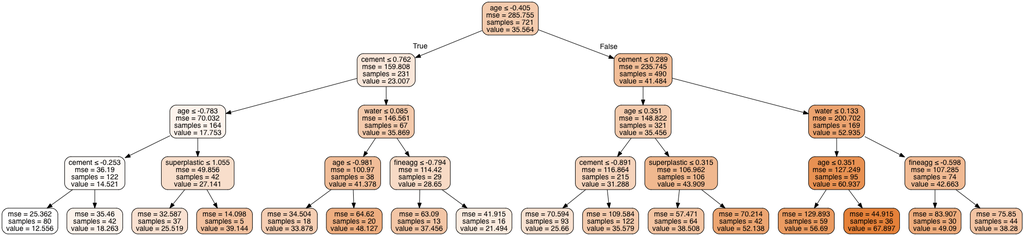

```python
dot_data = StringIO()
export_graphviz(dec_prun_model, out_file=dot_data,
                filled=True, rounded=True,
                special_characters=True,feature_names = feature_cols,class_names=['0','1'])
(graph,) = pydot.graph_from_dot_data(dot_data.getvalue())
graph.write_png('concrete_pruned.png')
Image(graph.create_png())
```

```python
y_pred = dec_prun_model.predict(X_test)
```

```python
dec_prun_model.score(X_train,y_train)
```

```
0.7578225840644413
```

```python
dec_prun_model.score(X_test,y_test)
```

```
0.556820999525816
```

```python
acc_DecT=metrics.r2_score(y_test, y_pred)
acc_DecT
```

```
0.556820999525816
```

```python
metrics.mean_squared_error(y_test, y_pred)
```

```
116.16040647585388
```

```python
DecT_df = pd.DataFrame({'Algorithm':['Pruned Decision Tree'], 'accuracy': [acc_DecT]},index={'17'})
results = pd.concat([results, DecT_df ])
results = results[['Algorithm', 'accuracy']]
results
```

|  | Algorithm | accuracy |
| --- | --- | --- |
| 1 | Random Forest | 0.877429 |
| 2 | Random Forest Regressor k_fold | 0.766505 |
| 3 | Gradient Boost Regressor | 0.880352 |
| 4 | Gradient Boost Regressor k fold | 0.770140 |
| 5 | Ada Boosting Regressor | 0.754750 |
| 6 | Ada Boosting Regressor k fold | 0.598713 |
| 7 | KNN Regressor | 0.753949 |
| 8 | KNN Regressor k fold | 0.690711 |
| 9 | Bagging Regressor | 0.871951 |
| 10 | Bagging Regressor k fold | 0.737566 |
| 11 | Support Vector Regressor | 0.654996 |
| 12 | SVR k fold | 0.668538 |
| 13 | XGBoast | 0.881806 |
| 14 | Decision Tree | 0.764992 |
| 15 | Decision Tree k fold | 0.768278 |
| 16 | Decision Tree2 | 0.745384 |
| 17 | Pruned Decision Tree | 0.556821 |

```python
k= 20

kfold = KFold(n_splits=k, random_state=70)
results_8 = cross_val_score(dec_prun_model,X, y, cv=kfold)
accuracy=np.mean(abs(results_8))
accuracy
```

```
0.44792037352404224
```

```python
decTKFold_df = pd.DataFrame({'Algorithm':['Pruned Decision Tree k fold'], 'accuracy': [accuracy]},index={'18'})
results = pd.concat([results, decTKFold_df])
results = results[['Algorithm', 'accuracy']]
results
```

|  | Algorithm | accuracy |
| --- | --- | --- |
| 1 | Random Forest | 0.877429 |
| 2 | Random Forest Regressor k_fold | 0.766505 |
| 3 | Gradient Boost Regressor | 0.880352 |
| 4 | Gradient Boost Regressor k fold | 0.770140 |
| 5 | Ada Boosting Regressor | 0.754750 |
| 6 | Ada Boosting Regressor k fold | 0.598713 |
| 7 | KNN Regressor | 0.753949 |
| 8 | KNN Regressor k fold | 0.690711 |
| 9 | Bagging Regressor | 0.871951 |
| 10 | Bagging Regressor k fold | 0.737566 |
| 11 | Support Vector Regressor | 0.654996 |
| 12 | SVR k fold | 0.668538 |
| 13 | XGBoast | 0.881806 |
| 14 | Decision Tree | 0.764992 |
| 15 | Decision Tree k fold | 0.768278 |
| 16 | Decision Tree2 | 0.745384 |
| 17 | Pruned Decision Tree | 0.556821 |
| 18 | Pruned Decision Tree k fold | 0.447920 |

NB: You can again drop the features that are not important and build the model on the important features again